# Descriptive Statistics

## Descriptive statistics for numeric data

Here will cover measures of central tendency, variability, and distribution shape for continuous variables.

### Summary Statistics for every column

R provides a wide range of functions for obtaining summary statistics. One method of obtaining descriptive statistics is to use the sapply( ) function with a specified summary statistic. Possible functions used in **sapply** include **mean, sd, var, min, max, median, range, and quantile**.

We mainly use two datasets to demonstrate: [mtcars](https://stat.ethz.ch/R-manual/R-devel/library/datasets/html/mtcars.html) and [iris](http://rstudio-pubs-static.s3.amazonaws.com/450733_9a472ce9632f4ffbb2d6175aaaee5be6.html)

Besides the R base package, a few other packages contain functions for descriptive statistical analysis, including packages Hmisc, pastecs, and psych.

### Summary Statistics by Group

A simple way of generating summary statistics by grouping variable is available in the psych package.

```r
library(psych)
with(iris, describeBy(iris, group = Species))
```

```
 Descriptive statistics by group
group: setosa
             vars  n mean   sd median trimmed  mad min max
Sepal.Length    1 50 5.01 0.35    5.0    5.00 0.30 4.3 5.8
Sepal.Width     2 50 3.43 0.38    3.4    3.42 0.37 2.3 4.4
Petal.Length    3 50 1.46 0.17    1.5    1.46 0.15 1.0 1.9
Petal.Width     4 50 0.25 0.11    0.2    0.24 0.00 0.1 0.6
Species*        5 50 1.00 0.00    1.0    1.00 0.00 1.0 1.0
             range skew kurtosis   se
Sepal.Length   1.5 0.11    -0.45 0.05
Sepal.Width    2.1 0.04     0.60 0.05
Petal.Length   0.9 0.10     0.65 0.02
Petal.Width    0.5 1.18     1.26 0.01
Species*       0.0  NaN      NaN 0.00
--------------------------------------------
group: versicolor
             vars  n mean   sd median trimmed  mad min max
Sepal.Length    1 50 5.94 0.52   5.90    5.94 0.52 4.9 7.0
Sepal.Width     2 50 2.77 0.31   2.80    2.78 0.30 2.0 3.4
Petal.Length    3 50 4.26 0.47   4.35    4.29 0.52 3.0 5.1
Petal.Width     4 50 1.33 0.20   1.30    1.32 0.22 1.0 1.8
Species*        5 50 2.00 0.00   2.00    2.00 0.00 2.0 2.0
             range  skew kurtosis   se
Sepal.Length   2.1  0.10    -0.69 0.07
Sepal.Width    1.4 -0.34    -0.55 0.04
Petal.Length   2.1 -0.57    -0.19 0.07
Petal.Width    0.8 -0.03    -0.59 0.03
Species*       0.0   NaN      NaN 0.00
--------------------------------------------
group: virginica
             vars  n mean   sd median trimmed  mad min max
Sepal.Length    1 50 6.59 0.64   6.50    6.57 0.59 4.9 7.9
Sepal.Width     2 50 2.97 0.32   3.00    2.96 0.30 2.2 3.8
Petal.Length    3 50 5.55 0.55   5.55    5.51 0.67 4.5 6.9
Petal.Width     4 50 2.03 0.27   2.00    2.03 0.30 1.4 2.5
Species*        5 50 3.00 0.00   3.00    3.00 0.00 3.0 3.0
             range  skew kurtosis   se
Sepal.Length   3.0  0.11    -0.20 0.09
Sepal.Width    1.6  0.34     0.38 0.05
Petal.Length   2.4  0.52    -0.37 0.08
Petal.Width    1.1 -0.12    -0.75 0.04
Species*       0.0   NaN      NaN 0.00
```

The doBy package provides much of the functionality of SAS PROC SUMMARY. It defines the desired table using a model formula and a function. Here is a simple example.

```r
library(doBy)
# produces mpg.m wt.m mpg.s wt.s for each
# combination of the levels of cyl and vs
summaryBy(mpg + wt ~ cyl + vs, data = mtcars,
  FUN = function(x) {c(m = mean(x, na.rm = TRUE),
                       s = sd(x, na.rm = TRUE))})
```

[output not shown]

## Summary statistics for categorical data

This section describes the creation of frequency and contingency tables from categorical variables, along with tests of independence, measures of association, and methods for graphically displaying results.

### Frequencies and crosstables

You can generate frequency tables using the table( ) function, tables of proportions using the prop.table( ) function, and marginal frequencies using margin.table( ).

```r
if (!require("vcd")) install.packages("vcd")
library(vcd)
head(Arthritis)
```

|  | ID | Treatment | Sex | Age | Improved |
| --- | --- | --- | --- | --- | --- |
| 1 | 57 | Treated | Male | 27 | Some |
| 2 | 46 | Treated | Male | 29 | None |
| 3 | 77 | Treated | Male | 30 | None |
| 4 | 17 | Treated | Male | 32 | Marked |
| 5 | 36 | Treated | Male | 46 | Marked |
| 6 | 23 | Treated | Male | 58 | Marked |

```r
# 2-Way Frequency Table
attach(Arthritis)
mytable <- table(Treatment, Sex) # A will be rows, B will be columns
mytable # print table
```

```
         Sex
Treatment Female Male
  Placebo     32   11
  Treated     27   14
```

```r
margin.table(mytable, 1) # A frequencies (summed over B)
```

```
Treatment
Placebo Treated
     43      41
```

```r
margin.table(mytable, 2) # B frequencies (summed over A)
```

```
Sex
Female   Male
    59     25
```

```r
prop.table(mytable) # cell percentages
```

```
         Sex
Treatment    Female      Male
  Placebo 0.3809524 0.1309524
  Treated 0.3214286 0.1666667
```

```r
prop.table(mytable, 1) # row percentages
```

```
         Sex
Treatment    Female      Male
  Placebo 0.7441860 0.2558140
  Treated 0.6585366 0.3414634
```

```r
prop.table(mytable, 2) # column percentages
```

```
         Sex
Treatment    Female      Male
  Placebo 0.5423729 0.4400000
  Treated 0.4576271 0.5600000
```

table( ) can also generate multidimensional tables based on 3 or more categorical variables. In this case, use the ftable( ) function to print the results more attractively.

```r
# 3-Way Frequency Table
mytable <- table(Treatment, Sex, Improved)
ftable(mytable)
```

```
                 Improved None Some Marked
Treatment Sex
Placebo   Female            19    7      6
          Male              10    0      1
Treated   Female             6    5     16
          Male               7    2      5
```

The xtabs( ) function allows you to create crosstabulations using formula style input.

```r
# 3-Way Frequency Table
mytable <- xtabs(~Treatment + Sex + Improved, data = Arthritis)
ftable(mytable) # print table
```

```
                 Improved None Some Marked
Treatment Sex
Placebo   Female            19    7      6
          Male              10    0      1
Treated   Female             6    5     16
          Male               7    2      5
```

```r
summary(mytable) # chi-square test of indepedence
```

```
Call: xtabs(formula = ~Treatment + Sex + Improved, data = Arthritis)
Number of cases in table: 84
Number of factors: 3
Test for independence of all factors:
    Chisq = 19.6, df = 7, p-value = 0.006501
    Chi-squared approximation may be incorrect
```

### Independence Tests

1. Chi-Square Test  
   For 2-way tables you can use chisq.test(mytable) to test independence of the row and column variable. By default, the p-value is calculated from the asymptotic chi-squared distribution of the test statistic. Optionally, the p-value can be derived via Monte Carlo simulation. If one cell of the table’s expected value is less than five, the chi-square approximation is applied and p-value is not reliable.

```r
library(vcd)
mytable <- xtabs( ~ Treatment + Improved, data = Arthritis)
chisq.test(mytable)
```

```
    Pearson's Chi-squared test

data:  mytable
X-squared = 13.055, df = 2, p-value = 0.001463
```

2. Fisher Exact Test  
   Fisher’s exact test evaluates the null hypothesis of independence of rows and columns in a contingency table with fixed marginals. If one cell of the table’s expected value is less than five, use Fisher’s exact test.

```r
mytable <- xtabs( ~ Treatment + Improved, data = Arthritis)
fisher.test(mytable)
```

```
    Fisher's Exact Test for Count Data

data:  mytable
p-value = 0.001393
alternative hypothesis: two.sided
```

### Measures of association

The significance tests evaluate whether sufficient evidence exists to reject a null hypothesis of independence between variables. If you can reject the null hypothesis, the you can use the assocstats() function in the vcd package to calculate the association: the phi coefficient, contingency coefficient, and Cramer’s V for a two-way table.

```r
library(vcd)
mytable <- xtabs( ~ Treatment + Improved, data = Arthritis)
assocstats(mytable)
```

```
                    X^2 df  P(> X^2)
Likelihood Ratio 13.530  2 0.0011536
Pearson          13.055  2 0.0014626

Phi-Coefficient   : NA
Contingency Coeff.: 0.367
Cramer's V        : 0.394
```

```r
detach(Arthritis)
```

### Visualizing results

Use bar charts for visualizing frequencies in one dimension.

Use the vcd package for visualizing relationships among categorical data (e.g. mosaic and association plots).

Use the ca package for correspondence analysis (visually exploring relationships between rows and columns in contingency tables).

## Correlations

Common types of correlations: Pearson CC, Spearman CC, and Kendall CC. to decide to use what type of correlation, always plot your data first to see the distribution of each variable and relationship between variables.

- Pearson product-moment correlation: the degree of linear relationship between two quantitative variables. Assumption: normal distributions, linearity and equal-variance. Normally distributed variables have a bell-shaped curve Linearity assumes a straight line relationship between each of the two variables and equal-variance assumes that data is equally distributed about the regression line.  
  Good examples where PCC applies.

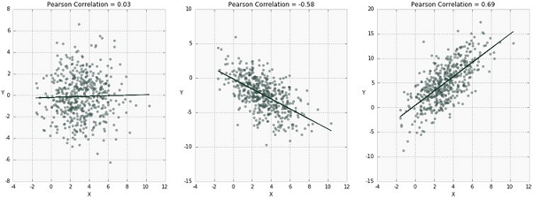

Misleading Pearson CC:

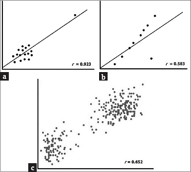

- Spearman’s rank-order correlation coefficient: the degree of relationship between two rank-ordered variables. The assumptions of the Spearman correlation are that data must be at least ordinal and the scores on one variable must be monotonically related to the other variable.

Good examples where SCC applies.

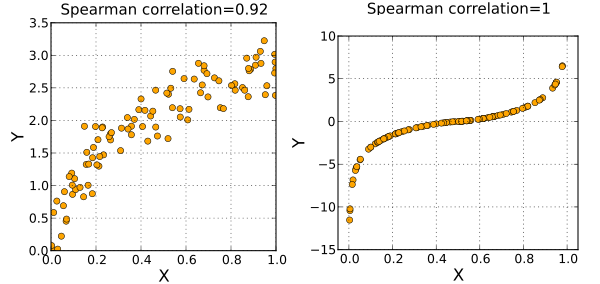

- Kendall rank correlation: a non-parametric test that measures the strength of dependence between two variables. If we consider two samples, a and b, where each sample size is n, we know that the total number of pairings with a b is n(n-1)/2. Kendall rank correlation = (Nc-Nd)/(n(n-1)/2),  
  where, Nc= number of concordant pair; Nd= Number of discordant pair.

Good examples of using Kendall CC.

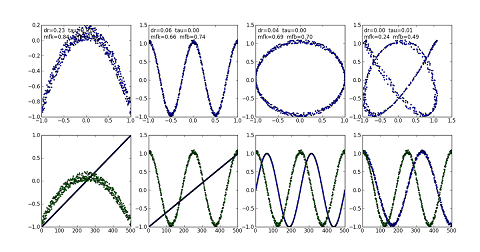

You can use the cor() function to produce correlations and the cov( ) function to produces covariances.

```r
cor(x, y = NULL, use = "everything",
    method = c("pearson", "kendall", "spearman"))

# use: Specifies the handling of missing data. Options are all.obs (assumes no missing data - missing data will produce an error), complete.obs (listwise deletion), and pairwise.complete.obs (pairwise deletion)
# method: Specifies the type of correlation. Options are pearson, spearman or kendall.
```

```r
# Correlation matrix from mtcars
# with mpg, cyl, and disp as rows
# and hp, drat, and wt as columns
x <- mtcars[1:3]
y <- mtcars[4:6]
cor(x, y)
```

```
             hp       drat         wt
mpg  -0.7767080  0.6048734 -0.8254413
cyl   0.8324475 -0.4812680  0.7140849
disp  0.7910818 -0.4895128  0.8487761
```

Use the cor.test( ) function to test a single correlation coefficient.

```r
cor.test(mtcars[,3], mtcars[,5])
```

```
    Pearson's product-moment correlation

data:  mtcars[, 3] and mtcars[, 5]
t = -3.0748, df = 30, p-value = 0.004462
alternative hypothesis: true correlation is not equal to 0
95 percent confidence interval:
 -0.7159937 -0.1698024
sample estimates:
       cor
-0.4895128
```

The rcorr( ) function in the Hmisc package produces correlations/covariances and significance levels for pearson and spearman correlations. However, input must be a matrix and pairwise deletion is used.

### Other Types of Correlations

```r
# polychoric correlation
# x is a contingency table of counts
library(polycor)
polychor(x)

# heterogeneous correlations in one matrix
# pearson (numeric-numeric),
# polyserial (numeric-ordinal),
# and polychoric (ordinal-ordinal)
# x is a data frame with ordered factors
# and numeric variables
library(polycor)
hetcor(x)

# partial correlations
library(ggm)
colnames(states)
pcor(c(1,5,2,3,6), cov(states))
# partial corr between columns 1 and 5 controlling for columns 2, 3, and 6
```